# Лабораторная работа №8

Текстовой редактор vi

Кузнецова С.В.

Российский университет дружбы народов, Москва, Россия

16 марта 2023

# Информация

## Докладчик

- Кузнецова София Вадимовна
- 16.03.2023
- Студент прикладной информатики
- Российский университет дружбы народов

# Цель

Познакомиться с операционной системой Linux. Получить практические навыки работы с редактором vi, установленным по умолчанию практически во всех дистрибутивах.

# Выполнение лабораторной работы

## Создание новых каталогов и вызов vi

vi hello.sh. (команда для вызова и создания файла)

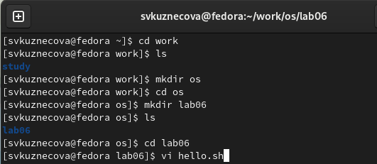

Создание новых каталогов и вызов vi

## Работа в vi

“i” - добавление иди изменение текста

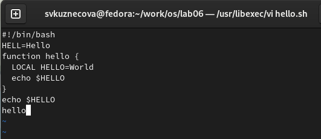

Добавление текста

## Работа vi

“Esc” - для перехода в командный режим. “:” - для перехода в режим последней строки. “w” -(запись) и “q”(выйти). “Enter” - для сохранения.

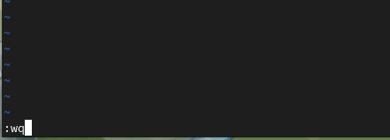

Запись и выход

## Исполняемый файл и его вызов на редактирование

Сделаем файл исполняемым и совершим вызов этого файла на редактирование.

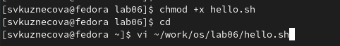

Исполняемый файл и его вызов на редактирование

## Замена слова

Установим курсор в конец слова HELL второй строки и перейдём в режим вставки и заменим на HELLO. Нажмите “Esc” для возврата в командный режим.

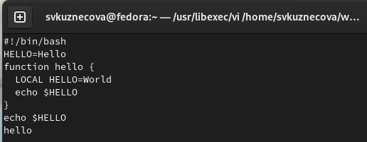

Замена слова

## Удаление слова и добавление нового

Теперь установим курсор на четвертую строку и сотрите слово LOCAL. Перейдём в режим вставки “i” и наберём local, нажмём “Esc” для возврата в командный режим.

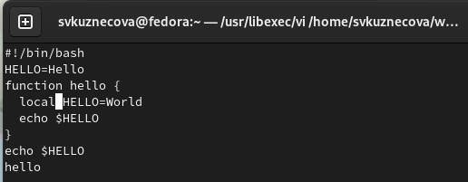

Удаление слова и добавление нового

## Добавление новой строки

Установим курсор на последнюю строку и вставим после неё строку, содержащую следующий текст: echo $HELLO.

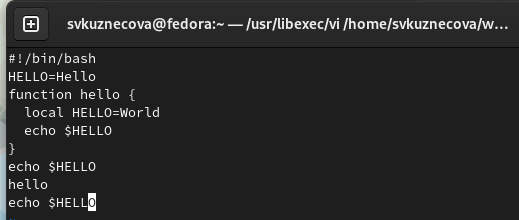

Добавление новой строки

## Удаление всей строки

“d” - двойное нажатие для удаления всей строки.

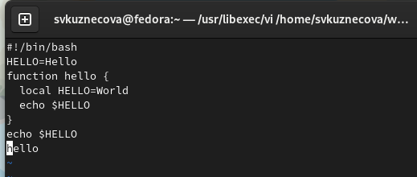

Удаление всей строки

## Отмена последней команды

“u” - для отмены последней команды.

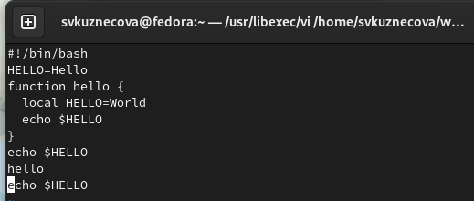

Отмена последней команды

# Вывод

Познакомилась с операционной системой Linux. Получила практические навыки работы с редактором vi, установленным по умолчанию практически во всех дистрибутивах.